# Type of occurences

Salima Jaoua

12/24/2021

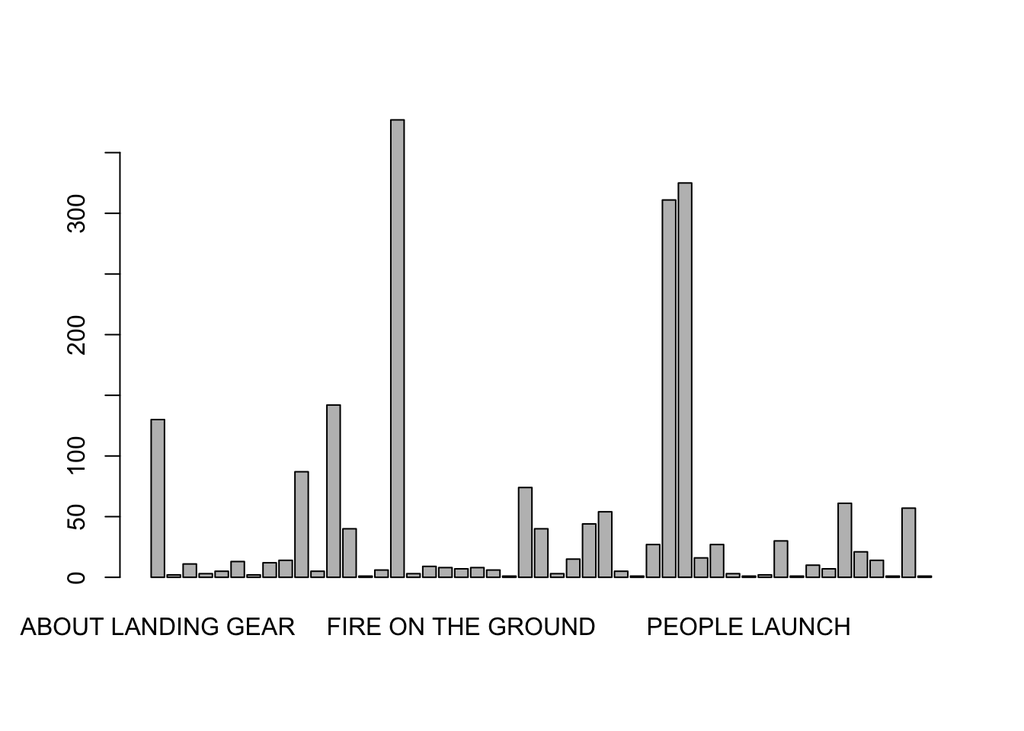

As you can see, there are a many causes of an accident to occur and working with these causes will be difficult. One idea is to divide the causes into different categories. We choose to divide into causes that occurs on the take off of the plane, during the flight, during the landing, in the ground and finally the causes that can occur in any time, that we denote unknown.

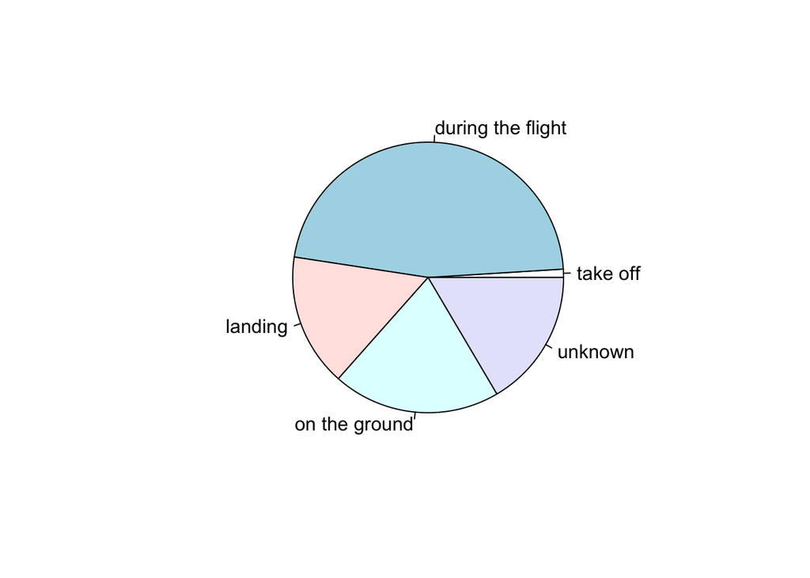

As you can see, most of the occurrences occurs during the flight. Surprisingly, there are a lot of occurences that occurs on the ground and a negligeable amount that occurs during the take off. Now we will study the severity of the accident depending on the causes. To do so we have two columns that we focus on : the classification of the accident if it was an incident or a serious accident and the damage level on the plane. First, let’s see how the classification can vary depending on the type of occurences. An accident is an occurrence where the flight has been stopped, a serious incident is an incident that involved circumstances that indicate a high probability of an accident.

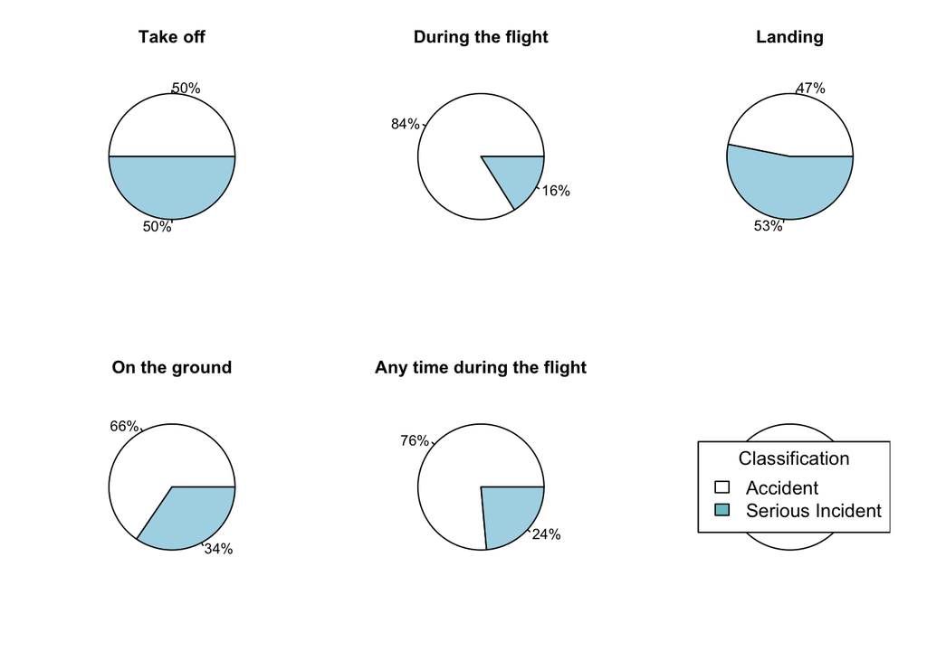

In most cases, most of the occurrences that happens are accidents. For the occurrences that happens during the landing, there are at 53% serious incident. To summarize we are going to plot the proportions of occurrences for each classification.

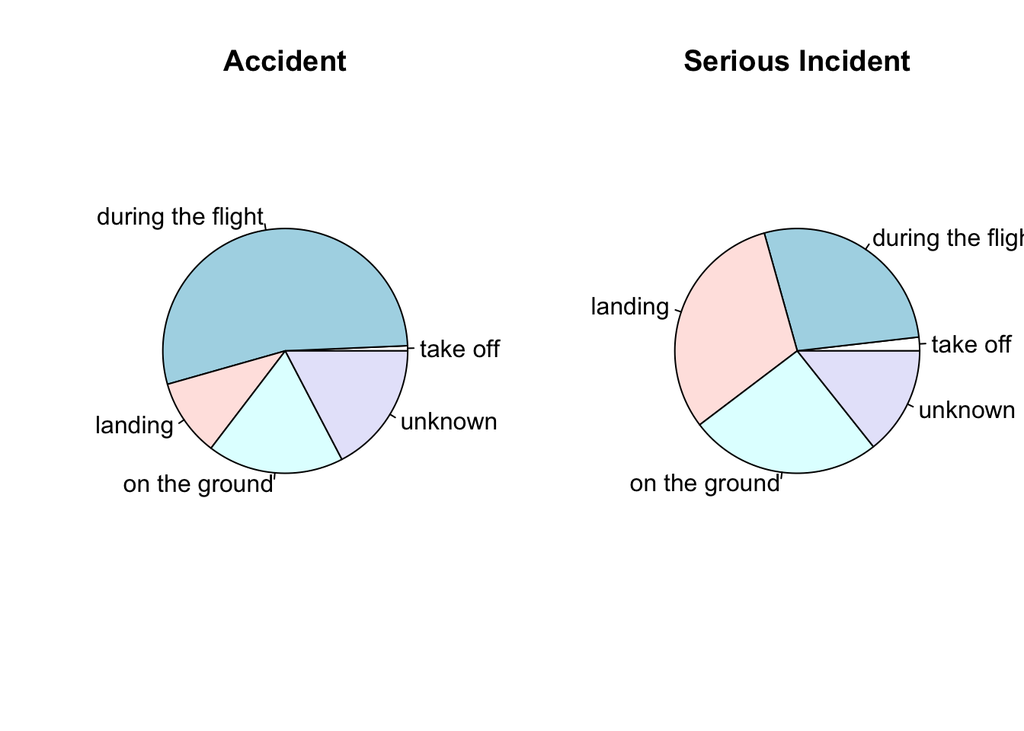

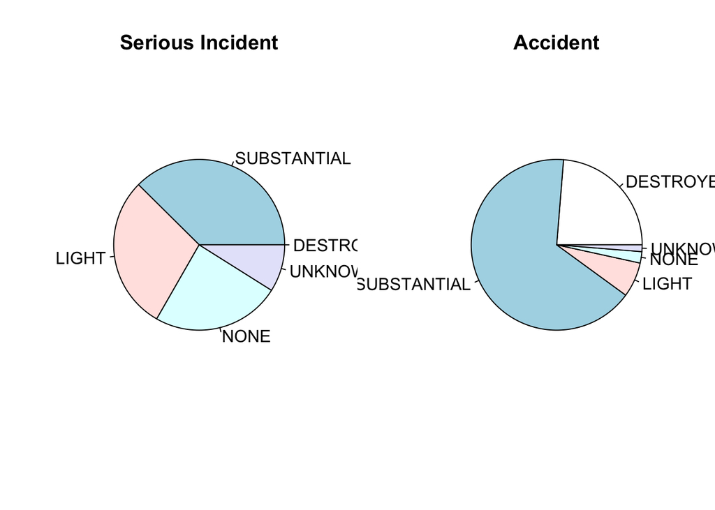

As we can see, incidents have more light or none damage and no destructive damage, where light and no damage are a small of accident’s damages. We can say that accident’s damages are more severe (approximetely 25% of aircrafts are destroyed during an accident compared to 0% during serious incidents). Of course, light damages occurred during accidents represent around 10% : that may be explained by accidents occurring on the ground and causing less damages. We now plot for each category, the proportion of damages.

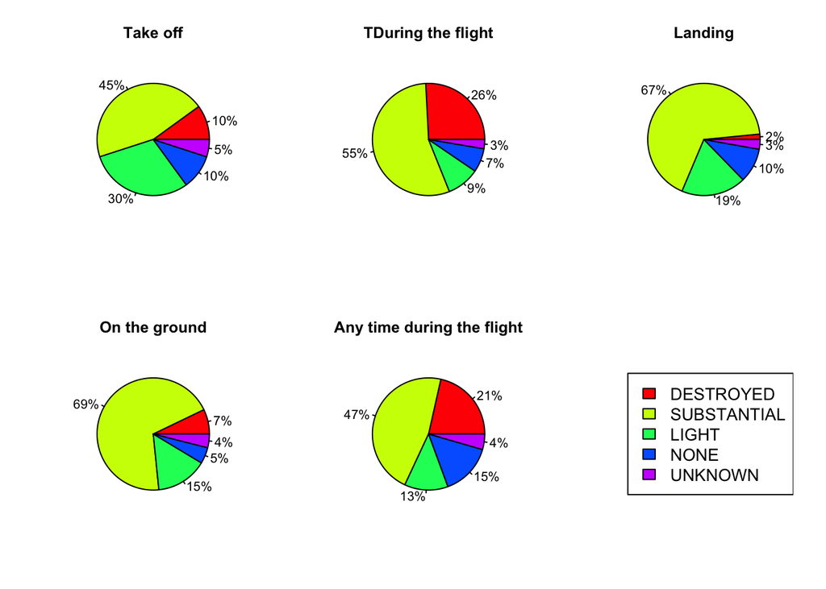